# Finding and Graphing Tangent Lines

The tangent line to the graph of $f(x)$ at the point $x = a$ has the equation $y = f(a) + f'(a)(x - a)$.

In this activity, we will use SymPy to find the equation of a tangent line to the graph of a function. Then, we will use matplotlib to graph tangent lines to a function.

We will use the following polynomial function as an example: $$f(x) = 4x^{4}-x^{3}-6x^{2}+x+1$$

## Preliminary Steps

First, we must import SymPy in order to work with symbolic expressions.

```python
from sympy import *
```

We let x be a symbol in SymPy, then define the function f in terms of x.

```python
x = symbols('x')
f = 4*x**4 - x**3 - 6*x**2 + x + 1
```

## Taking the Derivative

To take the derivative of a function in SymPy, use the **diff()** function.

- The first argument is the expression to be differentiated (in this case, f).
- The second argument is the variable (in this case, x).

Below, we store the derivative of f under the name **df**.

```python
df = diff(f, x)
df
```

$\displaystyle 16 x^{3} - 3 x^{2} - 12 x + 1$

## Tangent Line Equation

Below, we define a function in Python to give the tangent line equation at a point.

Given a number **a**, and the Python function prints the equation of the tangent line to the function $f(x)$ at the point $x = a$.

```python
def tangent_line_f(a):
    # Find the function value f(a)
    f_a = f.subs(x, a)
    # Find the slope of the tangent line f'(a)
    m = df.subs(x, a)
    # Substitute point and slope in tangent line equation
    return f_a + m*(x-a)
```

For example, we can use our Python function to find the equation of the tangent line to the graph of $f(x)$ at the point where $x = 1$.

```python
tangent_line_f(1)
```

$\displaystyle 2 x - 3$

## Graphing Tangent Lines

Let's graph $f(x)$ along with the tangent line at the point $x = 1$.

The following line allows us to use interactive plots in Jupyter notebooks.

```python
matplotlib notebook
```

We use the **plot()** function to generate the graphs.

To graph both $f(x)$ and the tangent line at $x = 1$ on the same set of coordinate axes, we add both **f** and **tangent_line_f(1)** as arguments to plot().

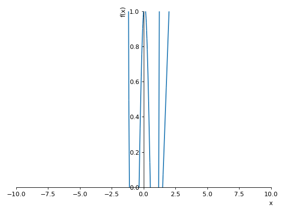

```
<sympy.plotting.plot.Plot at 0x71650e7b85d0>
```

```python
plot(f, tangent_line_f(1))
```

Try using the **tangent_line_f()** function to find the tangent lines to the graph of $f(x)$ at different points.